# CM3

David Martin

2024-08-08

# FICHE DE COURS n°3 : INTRODUCTION AUX TESTS STATISTIQUES (Partie 2)

Les tests que nous développerons dans ce cours seront mis en place lorsqu’une des deux variables sera qualitative et l’autre quantitative.

## CHAPITRE 3 : Variables quantitatives

### Statistiques descriptives et visualisations

L’ensemble de données de l’exemple ci-contre est issu d’un article paru dans Ecology (2023) intitulé *High sensitivity of tropical forest birds to deforestation at lower altitudes* par Mills SC, Socolar JB, Edwards FA, Parra E, Martínez-Revelo DE, Ochoa Quintero JM, Haugaasen T, Freckleton RP, Barlow J, Edwards DP (doi: 10.1002/ecy.3867). Vous pouvez retrouver cet article dans votre espace cours.

Il comprend des informations concernant le nombre d’espèces différentes observé sachant un paramètre de dépendence à la forêt. La survie des espèces d’oiseaux ont été classée comme étant moyennement dépendant de la forêt (“Medium.dependency”) ou bien fortement dépendant (“High.Dependency”). Enfin ce jeu de donnée présente la variable de l’atlitude moyenne associée à l’observation de ces espèces. Ces deux variables quantitatives sont associées à des sites géographiques de la cordillère des Andes (plus précisement en Colombie).

> Vous avez la possibilité de sauvegarder et d’uploader des datas en utilisant la forme de stockage RDATA ou rda. La fonction de stockage est save() et celle de chargement des données load().

```r
load(file="~/Dropbox/COURS/UBS/BIO1540/Package n°2/rawdata/Birds_dataset.rda")
knitr::kable(head(birds))
```

|  | Medium.dependency | High.Dependency | altitude |
| --- | --- | --- | --- |
| Arcabuco Togui | 142 | 100 | 2450.499 |
| Asiria Belen | 138 | 95 | 2893.601 |
| Chingaza | 127 | 85 | 3384.290 |
| Chiquaque | 142 | 100 | 2259.778 |
| El Secreto | 142 | 100 | 2320.463 |
| El Taladro | 142 | 100 | 2517.790 |

**Questions**

1. Quelle est la population d’intérêt ?
2. Les sites échantillonnés sont-ils représentatifs de la Colombie en terme d’altitude ?
3. Comment peut-on répondre à cette question ?

**Centre/position de la distribution** Un graphique est utile pour nous aider à visualiser la forme d’une distribution. Nous pouvons aussi résumer les caractéristiques importantes d’une distribution numériquement. Les deux statistiques qui décrivent le centre ou l’emplacement d’une distribution pour une seule variable quantitative sont la moyenne et la médiane.

La moyenne d’un échantillon de données $x_1, x_2,…, x_n$ et d’une variable $j$ (ici l’altitude) est définie par
$$\hat{\mu}_j = \frac{1}{n} \sum_{i=1}^{n}
x_{i}$$
Ici l’échantillonnage des oiseaux s’est réalisé en moyenne à 2297 mètres d’altitude soit $\hat{\mu}_{altitude} = 2297$

**Dispersion** La variance et l’écart-type donnent des informations sur la dispersion d’un échantillon.

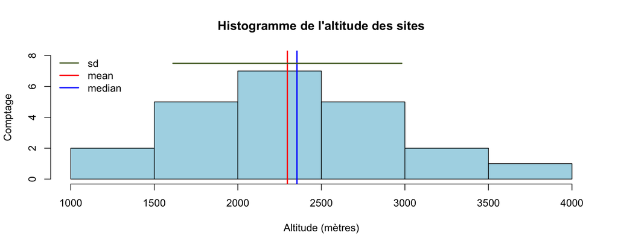

Figure 3 : Histogramme de l’Altitude.

```r
# Représenter la variable d'altitude.
hist(birds$altitude, col="lightblue", xlab="Altitude (mètres)",ylim=c(0,8),
     ylab="Comptage", main="Histogramme de l'altitude des sites")

# Représentation du paramètre de position.
abline(v=mean(birds$altitude), col='red', lwd=2)
abline(v=median(birds$altitude), col="blue", lwd=2)

# Représentation du paramètre de dispersion.
segments(x0 = mean(birds$altitude) - sd(birds$altitude),
         x1 = mean(birds$altitude) + sd(birds$altitude),
         y0 = 7.5, col="darkolivegreen", lwd=2)

# On ajoute une légende pour comprendre notre graphique.
legend("topleft", col=c("darkolivegreen","red","blue"), lty=1, legend = c("sd", "mean", "median"),
       lwd=2, bty="n")
```

Ces statistiques descriptives primaires permettent de décrire les observations. Dans le cas on nous représentons la moyenne avec plus ou moins 1 écart-type, nous engloberons environ 66% des observations. Dans le cas où nous aurions choisi de représenter la moyenne avec plus ou moins 2 écart-types, on engloberait environ 95% des observations. Enfin dans le cas où nous choisirions de représenter la moyenne avec plus ou moins 3 écart-types, on engloberait environ 99% des observations.

```r
length(which(birds$altitude>(mean(birds$altitude)-2*sd(birds$altitude))&
              birds$altitude<(mean(birds$altitude)+2*sd(birds$altitude))))/length(birds$altitude)
```

```
## [1] 0.9545455
```

Pour un échantillon $x_1, x_2,…, x_n$ et une variable $j$ (ici l’altitude), l’histogramme est défini par

$$\hat{f}(x) = \frac{1}{n} \sum_{i=1}^{n}
1_{[x-h/2, x+h/2[}(x_{i})$$
où h est la largeur de bande et $1_A(x)$ est la fonction indicatrice (ie elle vaut 1 si $x \in A$ et 0 sinon).

4. La dependance à la présence de forêt influence t’elle la diversité des groupes d’oiseaux ?
5. Répresentez le nombre d’espèces en fonction de l’altitude ? Que peut-on dire ? Y-a t’il un effet de l’altitude sur le nombre d’espèces.

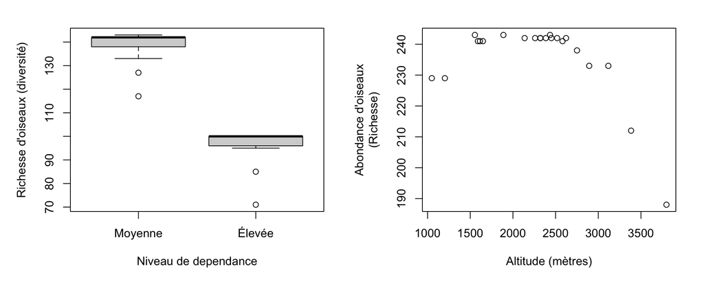

Figure 4 : Richesse en fonction de l’altitude.

```r
layout(matrix(c(1,2), nrow=1))
par(mar=c(5,5,2,2)) # Gérer les marges du plot.

# PLOT N°1
boxplot(birds$Medium.dependency,birds$High.Dependency, names = c("Moyenne", 'Élevée'), xlab='Niveau de dependance',
        ylab="Richesse d'oiseaux (diversité)")
# PLOT N°2
plot(birds$altitude, birds$Medium.dependency+birds$High.Dependency,
     xlab="Altitude (mètres)", ylab="Abondance d'oiseaux\n(Richesse)", main="")
```

6. La dependance à la présence de forêt influence t’elle la diversité des groupes d’oiseaux observée avec l’altitude ? Autrement dit, la décroissance liée à l’altitude est-elle plus importante dans l’un des deux groupes ?

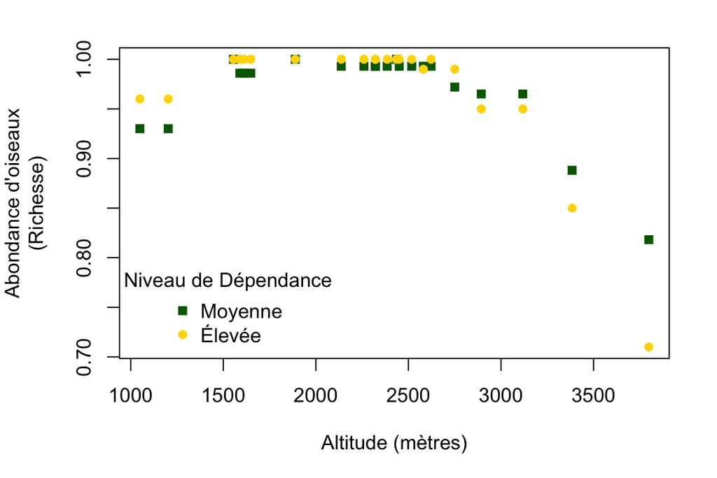

Figure 5 : Richesse en fonction de l’altitude et de leur dépendence à la forêt.

```r
par(mar=c(5,5,2,2)) # Gérer les marges du plot.
# Il faut d'abord normaliser les données pour pouvoir les comparer entre elles
# Plusieurs normalisation existe, ici nous normaliserons les données par rapport à leur maximum.
max.norm.M <- birds$Medium.dependency/max(birds$Medium.dependency)
max.norm.H <- birds$High.Dependency/max(birds$High.Dependency)

plot(birds$altitude, max.norm.M, xlab="Altitude (mètres)", ylab="Abondance d'oiseaux\n(Richesse)",
     main="", pch =15, col="darkgreen", ylim=range(c(max.norm.M,max.norm.H)))
points(birds$altitude, max.norm.H, pch=16, col="gold")
# Ajouter la légende.
legend("bottomleft", legend = c("Moyenne", "Élevée"), title="Niveau de Dépendance", pch=c(15,16), col=c("darkgreen", "gold"), bty="n")
```

> Quelles normalisations choisir pour comparer des données est un concept très important. Néanmoins il n’existe pas de recettes magiques. Tout dépend de l’analyse que vous souhaitez réaliser.

### Test Statistique pour variables quantitatives (Paramétriques / Non paramétriques)

#### Généralités

> Un test statistique (ou test d’hypothèses) utilise des données d’un échantillon pour décider entre deux hypothèses concernant une population en contrôlant le risque de se tromper.

Deux hypothèses : (1) L’altitude des sites/forêt d’echantillonnage sont similaires aux sites/forêts de la Colombie ou bien (2) l’altitude des sites/forêt d’echantillonnage sont différents aux sites/forêts de la Colombie (auxquels cas les conclusions de l’étude ne pourrait être généralisées sur l’ensemble de la colombie).

**Hypothèse nulle $H_0$**, l’hypothèse correspondant au cas où il n’y pas de différence. On dit que l’effet de la variable qualitative (Sites de l’étude / Sites de la Colombie) est nulle et on note :

$$H_0 : \mu_E = \hat{\mu}_P$$
$\mu_E$ et $\hat{\mu}_C$ sont respectivement l’altitude des sites échantillonés (dans l’étude) et l’altitude de l’ensemble des forêts/sites de la Colombie.

**Hypothèse alternative $H_1$**, dans l’hypothèse alternative, on indique que la variable qualitative (Sites de l’étude / Sites de la Colombie) a un effet.

$$H_1 : \mu_E \ne \hat{\mu}_P$$
Le problème consiste donc à décider entre les deux hypothèses : $H_0 : \hat{\mu}_M = \hat{\mu}_H$ contre $H_1 : \hat{\mu}_M \ne \hat{\mu}_H$.

#### Prérequis pour le choix du test

Les tests statistiques sont nombreux et vous devrez faire un choix par rapport aux propriétés des données sur lesquelles vous voulez tester des hypothèses. Les deux propriétés à vérifier avant de se lancer dans la réalisation d’un test sont (1) la normalité et (2) l’égalité des variances.

Pour la suite de l’exemple, notre objectif est de comparer les altitudes entre les sites de l’étude (variable $X$) et ceux de la Colombie (variable $Y$).

**1) Normalités**

Vous avez deux possibilités pour vérifier que votre échantillon est normal (i.e. qu’il suit une loi normale). Pour rappel, une loi normale est une distribution de probabilité qui dépend de 2 paramètres : une moyenne (qui décrit la position) et la variance (qui décrit la variabilité autour de la moyenne). Généralement, dans la nature 90% des processus sont gaussiens (taille, poids, nutrition, cholestérol, ASAT, QI, etc…).

> La vérification du test de normalité permet de savoir si vous réaliserez un test statitistique basé sur des paramètres (i.e. position et dispersion) ou bien sur autres choses que des paramètres estimée $\hat{\theta}$ de l’échantillon.

La normalité doit être validée de deux manières : visuellement et à l’aide d’un test statitistique.

> Rq : si la taille de l’échantillon est grande (typiquement supérieure à 30), on n’a pas besoin de varifier la normalité.

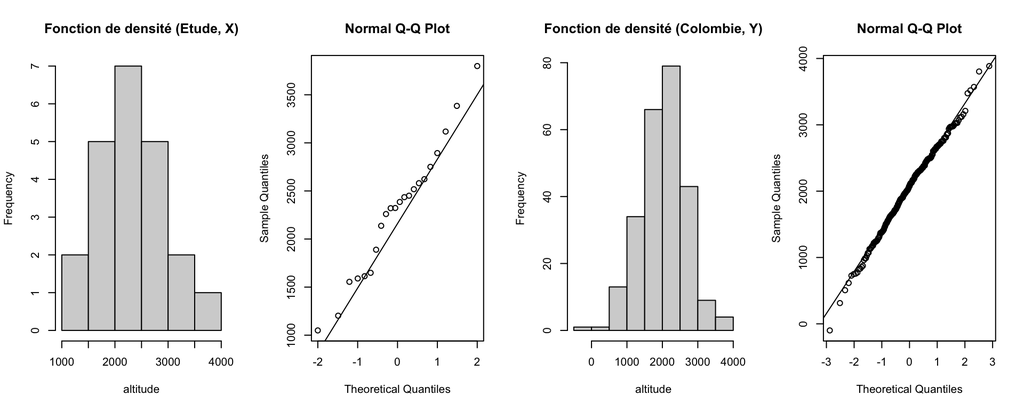

Figure 6 : Lois normales.

```r
layout(matrix(c(1:4), nrow=1, byrow = T))
Etude <- birds$altitude
Colombie <- c(rnorm(250, 2000, 700))

hist(Etude, main="Fonction de densité (Etude, X)", xlab="altitude")
qqnorm(Etude)
qqline(Etude)

hist(Colombie, main="Fonction de densité (Colombie, Y)", xlab="altitude")
qqnorm(Colombie)
qqline(Colombie)
```

1. Est-ce que les 2 variables vous semblent normales ?
2. L’estimation des paramètres (position et dispersion) serait représentatif et descriptif des variables $X$ et $Y$ ?

En pratique, on utilise un test de normalité pour vérifier si la variable est normale ou non.

3. Quelles sont les hypothèses du test de normalité (i.e. définir $H_0$, $H_1$) ?

Dans le cadre de ce cours, nous utiliserons le test de Shapiro-Wilk pour vérifier si la variable suit ou non une loi normale.

```r
shapiro.test(Etude)
```

```
##
##  Shapiro-Wilk normality test
##
## data:  Etude
## W = 0.97695, p-value = 0.8623
```

```r
shapiro.test(Colombie)
```

```
##
##  Shapiro-Wilk normality test
##
## data:  Colombie
## W = 0.99572, p-value = 0.7229
```

4. Pour quelle variable accepte t’on $H_O$ ? Pour quelle variable refusons nous $H_0$ ?

**2) Analyse des variances**

Dans un deuxième temps, il nous est nécessaire de vérifier si les échantillons possèdent une variance similaire. De la même manière, définissez quelles sont les hypothèses du test variance (i.e. définir $H_0$, $H_1$) entre $X$ et $Y$ ?

1. De la même manière que pour la normalité, vous pouvez visualiser les données pour voir rendre compte de leur variance ? Vous pouvez aussi estimer leur paramètre de dispersion, si les valeurs sont proches il y a des chances pour que l’on accepte $H_0$ (i.e. pas de différence de variance entre les deux variables).

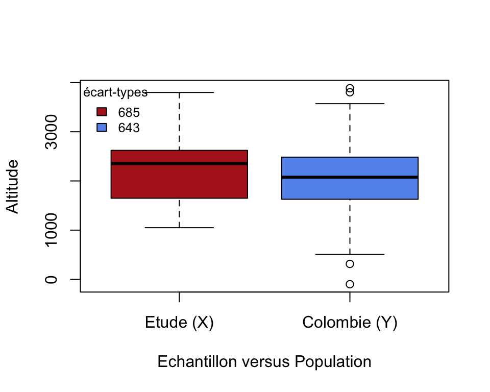

Figure 7 : Étude des variances (paramètre de dispersion).

```r
boxplot(Etude, Colombie, names = c("Etude (X)", "Colombie (Y)"), ylab="Altitude",
        xlab="Echantillon versus Population", col=c("firebrick", "cornflowerblue"))
legend("topleft", legend = c(round(sd(Etude), 0),round(sd(Colombie), 0)), fill=c("firebrick", "cornflowerblue"), bty="n", cex=0.8, title = "écart-types")
```

Le test de Fisher-Snedecor est un test paramétrique qui permet de comparer les variances de deux échantillons indépendants. Pour plus de 2 échantillons, on utilise le test de Bartlett.

```r
var.test(Etude, Colombie)
```

```
##
##  F test to compare two variances
##
## data:  Etude and Colombie
## F = 1.134, num df = 21, denom df = 249, p-value = 0.626
## alternative hypothesis: true ratio of variances is not equal to 1
## 95 percent confidence interval:
##  0.6495897 2.3556917
## sample estimates:
## ratio of variances
##           1.133952
```

Nous pouvons faire les hypothèses selon lesquels la variable *Altitude* suit une loi normale dans les deux groupes (étude et Population) et avec des variances égales.

#### Test paramétrique (test de Student)

On s’intéresse naturellement à l’écart entre les moyennes et on veut savoir si cet écart est loin ou non de 0. Et la variabilité de l’échantillon, mesurée par l’écart-type a bien sûr un impact sur la façon dont on considère le “loin de 0”. C’est pour cette raison que l’on doit en tenir compte.

Comme pour l’ensemble des tests statistiques, la première étape est de calculer une statistique (ici $T$, la statistique de test T de Student) et de savoir si la probabilité de cette statitique est rare ou commune **sous H0**. Plus elle sera rare, et plus la p value sera faible. On pourra alors prendre une décision (avec le risque d’erreur associée, la p value) sur l’hypothèse à choisir.

**1) Test de Student (variances égales)**

Si les variances sont égales entre les variables $X$ et $Y$ et qu’elles suivent des lois normales alors nous utiliserons un test de Student avec l’option variance égale. Nous allons d’abord le calculer à la main pour comprendre comment il fonctionne, voici la formule de la statistique $T$ :

$$T =
\frac{\hat{\mu}_{X}-\hat{\mu}_{Y}}{\sqrt{\frac{S^2_P}{n_X}+\frac{S^2_P}{n_Y}}}$$
où $S^2_P$ est l’estimation combinée de la variance (pooled variance) et se calcule comme suit :

$$S^2_P =
\frac{(n_X−1)S_X^2+(n_Y−1)S_Y^2}{n_X+n_Y-2}$$
où S correspond à la variance de $X$ ou de $Y$.

1. Calculer la statistique $T$ pour la variable *Altitude* dans les deux groupes (Sites de l’étude et Sites de la Colombie) ?

```r
n_x <- length(Etude) # on enregistre le nombre d'observations dans X
n_y <- length(Colombie) # on enregistre le nombre d'observations dans Y
## On calcul les variances
var_x <- var(Etude) # on enregistre la variance de X
var_y <- var(Colombie) # on enregistre la variance de Y
## On calcul les moyennes
mu_x <- mean(Etude)
mu_y <- mean(Colombie)
## On calcul la variance poolée
S2_P <- ((n_x-1)*var_x + (n_y-1)*var_y)/(n_x+n_y-2)

## On peut finalement calculer la Statistique T
S_T = (mu_x-mu_y) / sqrt(S2_P/(n_x-1) + S2_P/(n_y-1))
print(S_T)
```

```
## [1] 1.723133
```

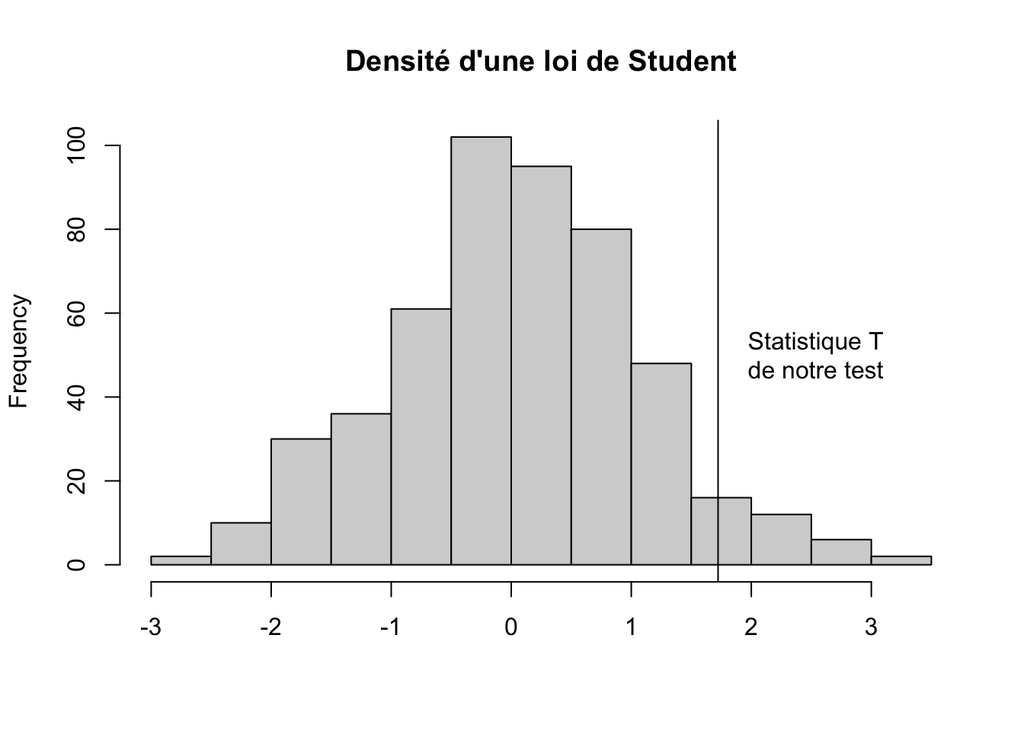

```r
loi_de_student <- rt(500, 270)
hist(loi_de_student, main="Densité d'une loi de Student", xlab="") # On construit une loi de student pour replacer notre statistique de T et calculer sa probabilité (i.e. sa rareté).
abline(v=S_T)
text(x=S_T+0.25,y=50 , "Statistique T\nde notre test", adj=0, xpd="NA")
```

Pour rappel une probabilité est comprise entre 0 et 1. Il faut calculer l’aire des histogrammes qui sont supérieures à notre statistique de T que nous avons représentée par une **ligne noire**.

```r
length(which(loi_de_student>S_T))/500
```

```
## [1] 0.048
```

```r
## On peut aussi calculer la probabilité d'observer la statistique T calculée directement avec la fonction de probabilité.
1-pt(S_T ,270)
```

```
## [1] 0.04300467
```

2. La probabilité d’observer cette différence de moyenne est-elle rare ?
3. Quelle est la p value ?
4. Quelle conclusion pouvez vous faire à partir de ces résultats ? Quelle est la probabilité d’erreur associée à votre prise de décision ?

> Plus rapidement, vous pouvez calculer la statistique T et sa p value associée avec la fonction t.test() sur R en ajoutant bien l’argument *var.equal = T*.

```r
t.test(Etude, Colombie, var.equal = T)
```

```
##
##  Two Sample t-test
##
## data:  Etude and Colombie
## t = 1.7607, df = 270, p-value = 0.07942
## alternative hypothesis: true difference in means is not equal to 0
## 95 percent confidence interval:
##  -29.90991 536.09456
## sample estimates:
## mean of x mean of y
##  2296.509  2043.416
```

5. Pourquoi observons-nous une différence dans la p.value du test R et de celui que nous avons calculé à la mains ?

**2) Test de Student (variances inégales)**

Dans le cas où les variances ne sont pas égales, vous pouvez utilisez la même fonction dans R en utilisant l’argument *var.egal = F*. Attention, les variables doivent toujours être des variables normales.

> Quelle est la conclusion de l’étude des oiseaux par rapport à la qualité d’échantillonnage de l’étude des oiseaux ? Pour rappel, $H_0$ l’altitude des sites d’échantillonage est représentatif des sites/forêts en Colombie.

**3) Test de Student (Apparié)**

Dans le cas, on les observations/individus serait les mêmes dans les deux groupes. Par exemple, un même groupe de patient que l’on suit au cours du temps, il faudrait ajouter l’argument *paired = T* dans la fonction de *t.test(X, Y, paired = T)*

#### Test non paramétrique (test de Wilcoxon-Mann-Whitney)

Si la variable d’intérêt ne suit pas une loi normale, i.e. qu’on ne peut se baser sur la moyenne et l’écart type pour calculer une statistique de test, il faut alors changer d’approche et calculer une statistique de test non paramétrique. Nous en verrons une pendant l’UE BIO1540 et une seconde pendant l’UE MTH1640.

Dans cette UE, nous allons voir le Test de Wilcoxon. Il permet de comparer permet de comparer les positions de 2 échantillons $X = \{x_1,··· ,x_n\}$ et $Y = \{y_1,··· ,y_m\}$.

$H_0 : \hat{\theta}_x=\hat{\theta}_y$ contre $H_1 : \hat{\theta}_x \neq \hat{\theta}_y$y

où $\hat{\theta}$ est par exemple l’estimation de la médiane.

- Il ne requiert pas d’hypothèse sur la distribution dont sont issues les données.
- En pratique on regroupe les 2 échantillons en un seul $z = \{X,Y\}$ et on attribue un rang à chacune des observations de $z: z_{(1)} ≤ z_{(2)} ≤ ··· ≤ z_{(n+m)}$

La statistique de test de Wilcoxon est

$$S_w = R_X - \frac{n(n+1)}{2}$$
où $R_X$ est la somme des rangs qui viennent de l’échantillon $X$. Globalement, la statistique de ce test évalue l’éloignement de la distribution des rangs d’une variable par rapport à une distribution des rangs alternés parfaitement entre les $X$ et les $Y$.

Prenons comme exemple un jeu de données simulées de la diversité d’oiseaux dans les forêts Alpestres françaises. Nous souhaitons savoir quelles sont les forêts qui possèdent une diversité d’oiseaux plus importante ?

1. Quels sont les hypothèses ?
2. Visualiser les données.
3. Calculer la statistique $S_w$.

```r
Colombian_birds <- (birds$Medium.dependency+birds$High.Dependency)+rnorm(22,0, 1)
French_birds <- c(rnorm(10, 200, 50),rnorm(10, 250, 10))

df <- data.frame(Pays = c(rep("Colombie", length(Colombian_birds)),rep("France", length(French_birds))) ,
           diversity = c(Colombian_birds, French_birds))

R_X <- sum(rank(df$diversity)[which(df$Pays=="France")]) # On récupère la somme des rangs associées au oiseaux de la France.

42*(42+1)/2
```

```
## [1] 903
```

```r
sum(rank(df$diversity))
```

```
## [1] 903
```

```r
R_X-sum(rank(df$diversity))
```

```
## [1] -456
```

De la même manière que pour les autres tests statistiques, la statistique calculée nous permet de savoir si l’évènement est rare sous $H_0$ auquel cas sa probabilité (p value) d’être observée sera faible.

```r
wilcox.test(diversity~Pays, data=df)
```

```
##
##  Wilcoxon rank sum exact test
##
## data:  diversity by Pays
## W = 203, p-value = 0.6809
## alternative hypothesis: true location shift is not equal to 0
```

4. Quelle décision prendrez-vous ?

**Test de Wilcoxon (Apparié)**

Dans le cas, on les observations/individus serait les mêmes dans les deux groupes. Par exemple, un même groupe de patient que l’on suit au cours du temps, il faudrait ajouter l’argument *paired = T* dans la fonction de *wilcox.test(X, Y, paired = T)*.

> A retenir : les tests statistiques présentés nous donne une probabilité que les différences dans nos données sont rares ou communes. La prise de décision dépend de vous et des erreurs que vous êtes prêts à faire.